# Análisis descriptivo de las estadísticas ofensivas para la temporada 2018-19 de la NBA

Acuña Alexandra, Gutiérrez Mayerlin, Martins Andrea, Mosqueda Michelle, Urbina Elvin, Prof. Jesús Ochoa

8 de noviembre de 2023

## Resumen

Implica examinar y resumir de manera detallada las métricas y datos relacionados con el rendimiento ofensivo de los equipos durante esa temporada específica. El estudio puede incluir diversas métricas como promedio partidos ganados (W), puntos anotados (PTS), porcentaje de tiros de campo exitosos (FG%), porcentaje de tiros de tres puntos exitosos (3P%), Tiros libres exitosos (FTM) y total de rebotes (REB). El objetivo del análisis descriptivo es proporcionar una visión global del desempeño ofensivo de los equipos en términos de producción de puntos y eficacia en el ataque. Se pueden identificar tendencias, comparaciones entre equipos destacados y áreas de fortaleza o debilidad en el rendimiento ofensivo de cada uno. Este tipo de análisis resulta inmedible para la toma de decisiones estratégicas y la evaluación del rendimiento colectivo de los equipos en la temporada 2018-19 de la NBA. Permite la comprensión de patrones y tendencias que pueden tener un impacto en la estrategia de juego y en la planificación para temporadas futuras.

Palabras claves: NBA, Baloncesto, Equipos, temporada 2018-19

## Introducción

En el ámbito del baloncesto profesional, la NBA destaca como la máxima competición a nivel mundial. Para comprender a fondo el rendimiento de los equipos durante la temporada 2018-19, resulta crucial realizar un análisis detallado de sus estadísticas ofensivas. Este enfoque se centra especialmente en cómo los equipos se desempeñaron colectivamente, permitiendo identificar tendencias, puntos fuertes y áreas de mejora en el aspecto ofensivo del juego. Examinar en detalle parámetros clave como el promedio de puntos por partido, la eficacia en tiros de campo, el porcentaje de aciertos en tiros de tres puntos y otras métricas pertinentes proporcionará una perspectiva precisa del desempeño ofensivo. El objetivo principal de este análisis es revelar los factores que influyeron en el éxito o las dificultades ofensivas de los equipos durante la temporada 2018-19 de la NBA. Los resultados obtenidos tendrán un impacto significativo en la comprensión de los patrones de juego y en la formulación de estrategias para futuras temporadas.

## Método

Los datos en los que se basa este estudio proceden de las estadísticas de equipo oficial de la NBA de baloncesto, correspondiente a la Liga regular de la temporada 2018-2019. Este análisis incluye la totalidad de los 30 equipos participantes en esa temporada. Cabe destacar que se jugaron 82 partidos (GP) durante la temporada regular. A continuación se presentan las variables que se han tomado para este estudio y que serán objeto de análisis. Las variables que se analizan son principalmente cuantitativas, ya que se refieren a medidas numéricas que describen el rendimiento de los equipos en términos de partidos ganados (W), puntos anotados (PTS), Tiros libres exitosos (FTM), porcentaje de tiros de campo exitosos (FG%), porcentaje de tiros de tres puntos exitosos (3P%), y total de rebotes (REB). Por lo tanto, las variables que se considerarán en este análisis serían de tipo cuantitativo, ya que se refieren a cantidades numéricas que se pueden medir y sobre las cuales se pueden realizar operaciones matemáticas. También se pueden incluir variables cualitativas que proporcionen contexto o categorización adicional como equipos. Calculamos medidas de tendencia central como la media, mediana y Medidas de Dispersión para las variables clave, incluyendo partidos ganados (W), puntos anotados (PTS) , porcentaje de tiros de campo exitosos (FG%), porcentaje de tiros de tres puntos exitosos (3P%), Tiros libres exitosos (FTM) y total de rebotes (REB). Además de las medidas de tendencia central, se busca explorar la distribución de las estadísticas entre los equipos. Se examinará cómo se distribuyen las variables de interés, como partidos ganados, porcentaje de victorias, puntos anotados, porcentaje de tiros de campo, porcentaje de tiros de tres puntos y total de rebotes, entre los 30 equipos participantes. Antes de realizar el análisis, se llevó a cabo un proceso de limpieza de datos para abordar posibles valores atípicos, datos faltantes o inconsistencias. El análisis y procesamiento de datos se realizaron utilizando la herramienta R.

## *Tabla 1. Análisis descriptivo de las variables estudiadas*

En la siguiente tabla, se encuentran las medidas de tendencias central: media, moda y mediana Medidas de Dispersión: Desviación Estándar, Varianza y Forma de la Distribución: Curtosis de los (n=30) equipos de la temporada 2018-19 de la NBA, de las variables partidos ganados (W), puntos anotados (PTS), porcentaje de tiros de campo exitosos (FG%), porcentaje de tiros de tres puntos exitosos (3P%), Tiros libres exitosos (FTM) y total de rebotes (REB).

| Variable | Media | Moda | Mediana | Varianza | Desviacion_Estandar | Kurtosis |
| --- | --- | --- | --- | --- | --- | --- |
| W | 41.00 | 33.00 | 41.50 | 144.69 | 12.03 | -0.85 |
| PTS | 111.20 | 110.70 | 112.00 | 16.75 | 4.09 | -1.07 |
| FG% | 46.05 | 44.90 | 46.15 | 1.75 | 1.32 | -0.70 |
| 3P% | 35.55 | 35.10 | 35.25 | 2.35 | 1.53 | 0.03 |
| FTM | 17.68 | 15.80 | 17.70 | 2.87 | 1.69 | 0.72 |
| REB | 45.17 | 44.70 | 45.35 | 4.46 | 2.11 | -0.43 |

## Tabla 2. *Equipos con Mejor y Peor Desempeño*

Esta tabla resumen muestra, para cada métrica seleccionada (victorias, puntos, porcentaje de tiros de campo, porcentaje de triples, Tiros libres exitosos (FTM)y rebotes), el equipo con el mejor y peor desempeño de los n=30 equipos de la temporada 2018-19 de la NBA.

| Metrica | Mejor_Equipo | Peor_Equipo |
| --- | --- | --- |
| W | Milwaukee Bucks | New York Knicks |
| PTS | Milwaukee Bucks | Memphis Grizzlies |
| FG% | Golden State Warriors | New York Knicks |
| 3P% | San Antonio Spurs | Phoenix Suns |
| FTM | LA Clippers | Orlando Magic |
| REB | Milwaukee Bucks | Phoenix Suns |

[output not shown]

6 rows

## Figura 1. Grafico de líneas Comparación de Estadísticas entre el Mejor y Peor Equipo.

El gráfico muestra cómo varían las métricas entre el mejor y peor equipo a lo largo de diferentes categorías.

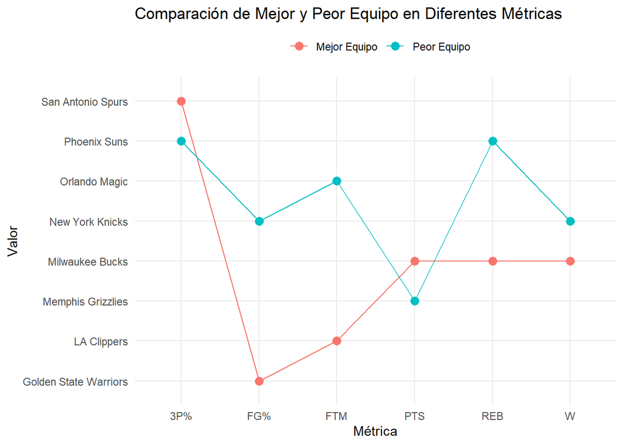

## Tabla 3. *Distribución de Frecuencia de Partidos ganados (W)*

La siguiente tabla brinda una visión estructurada y detallada de cómo se distribuyeron los partidos ganados entre los equipos durante la temporada 2018-19 de la NBA.

| Partidos_Ganados | Frecuencia_Absoluta | Frecuencia_Acumulada | Frecuencia_Relativa | Frecuencia_Relativa_Acumulada |
| --- | --- | --- | --- | --- |
| 17 | 1 | 1 | 0.03 | 0.03 |
| 19 | 2 | 3 | 0.07 | 0.10 |
| 22 | 1 | 4 | 0.03 | 0.13 |
| 29 | 1 | 5 | 0.03 | 0.17 |
| 32 | 1 | 6 | 0.03 | 0.20 |
| 33 | 3 | 9 | 0.10 | 0.30 |
| 36 | 1 | 10 | 0.03 | 0.33 |
| 37 | 1 | 11 | 0.03 | 0.37 |
| 39 | 3 | 14 | 0.10 | 0.47 |
| 41 | 1 | 15 | 0.03 | 0.50 |
| 42 | 2 | 17 | 0.07 | 0.57 |
| 48 | 3 | 20 | 0.10 | 0.67 |
| 49 | 2 | 22 | 0.07 | 0.73 |
| 50 | 1 | 23 | 0.03 | 0.77 |
| 51 | 1 | 24 | 0.03 | 0.80 |
| 53 | 2 | 26 | 0.07 | 0.87 |
| 54 | 1 | 27 | 0.03 | 0.90 |
| 57 | 1 | 28 | 0.03 | 0.93 |
| 58 | 1 | 29 | 0.03 | 0.97 |
| 60 | 1 | 30 | 0.03 | 1.00 |

## Figura 2. Histograma de Partidos Ganados por equipo (W)

Este Histograma representa la distribución de partidos ganados por equipo para la temporada 2018-2019 de la NBA. En el eje x se encuentran partidos ganados equipos, y en el eje y se muestra la frecuencia de partidos ganados.

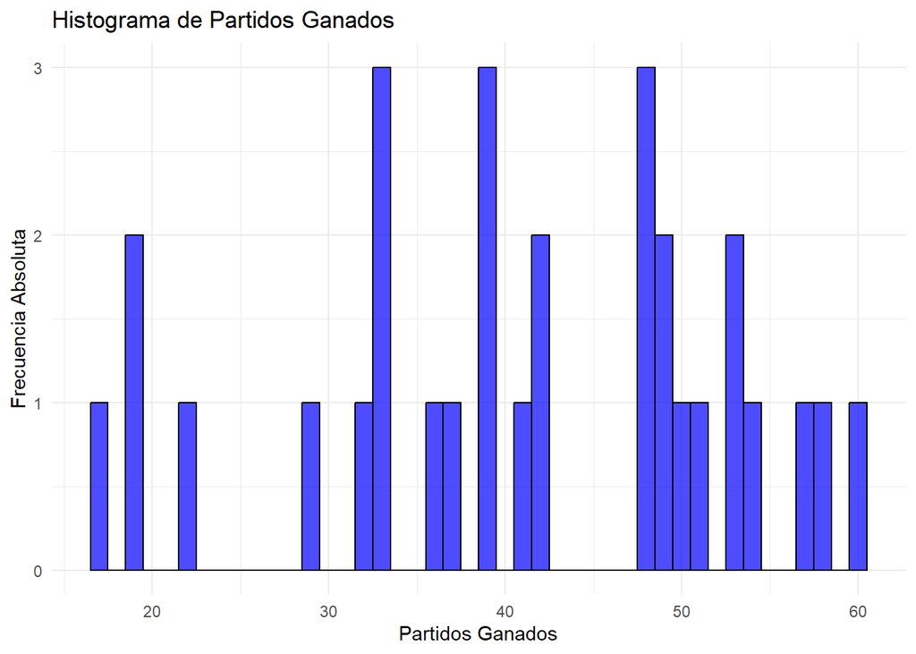

## Tabla 4. *Datos: Puntos Anotados (PTS) y Porcentaje de Tiros de Campo Exitosos (FG%)*

Esta tabla presenta datos de puntos anotados (PTS) y porcentaje de tiros de campo exitosos (FG%) para los equipos de la NBA en la temporada 2018-19. La información se muestra por equipo.

Datos de Puntos Anotados (PTS) y Porcentaje de Tiros de Campo Exitosos (FG%)

| TEAM | PTS | FG% |
| --- | --- | --- |
| Milwaukee Bucks | 118.1 | 47.6 |
| Toronto Raptors | 114.4 | 47.4 |
| Golden State Warriors | 117.7 | 49.1 |
| Denver Nuggets | 110.7 | 46.6 |
| Houston Rockets | 113.9 | 44.9 |
| Portland Trail Blazers | 114.7 | 46.7 |
| Philadelphia 76ers | 115.2 | 47.1 |
| Utah Jazz | 111.7 | 46.8 |
| Boston Celtics | 112.4 | 46.5 |
| Oklahoma City Thunder | 114.5 | 45.4 |
| Indiana Pacers | 108.0 | 47.5 |
| LA Clippers | 115.1 | 47.1 |
| San Antonio Spurs | 111.7 | 47.8 |
| Brooklyn Nets | 112.2 | 44.9 |
| Orlando Magic | 107.3 | 45.4 |
| Detroit Pistons | 107.0 | 44.0 |
| Charlotte Hornets | 110.7 | 44.8 |
| Miami Heat | 105.7 | 45.0 |
| Sacramento Kings | 114.2 | 46.4 |
| Los Angeles Lakers | 111.8 | 47.0 |
| Minnesota Timberwolves | 112.5 | 45.6 |
| Dallas Mavericks | 108.9 | 44.7 |
| Memphis Grizzlies | 103.5 | 45.0 |
| New Orleans Pelicans | 115.4 | 47.3 |
| Washington Wizards | 114.0 | 46.8 |
| Atlanta Hawks | 113.3 | 45.1 |
| Chicago Bulls | 104.9 | 45.3 |
| Cleveland Cavaliers | 104.5 | 44.4 |
| Phoenix Suns | 107.5 | 45.9 |
| New York Knicks | 104.6 | 43.3 |

## Figura 3. Gráfica de Dispersión: Puntos Anotados (PTS) vs. Porcentaje de Tiros de Campo Exitosos (FG%)

Representa la relación entre dos variables: los puntos anotados (PTS) y el porcentaje de tiros de campo exitosos (FG%) para los equipos de la NBA en la temporada 2018-19. El éxito ofensivo de un equipo (medido por los puntos anotados) está relacionado positivamente con el porcentaje de tiros de campo exitosos.

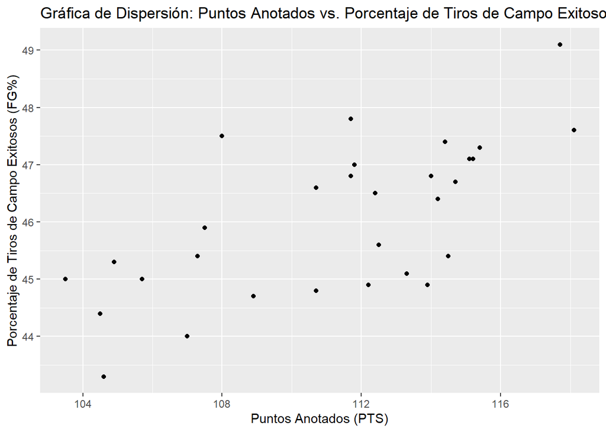

## Tabla 5. *Distribución de frecuencia de puntos anotados (PTS) de los equipos en la temporada 2018-19 de la NBA*

La siguiente tabla refleja la frecuencia con la que los equipos de la NBA anotaron diferentes cantidades de puntos incluye información sobre la cantidad exacta de puntos anotados, la frecuencia con la que se produjo cada cantidad de puntos.

| Puntos_Anotados | Frecuencia_Absoluta | Frecuencia_Acumulada | Frecuencia_Relativa | Frecuencia_Relativa_Acumulada |
| --- | --- | --- | --- | --- |
| 103.5 | 1 | 1 | 0.03 | 0.03 |
| 104.5 | 1 | 2 | 0.03 | 0.07 |
| 104.6 | 1 | 3 | 0.03 | 0.10 |
| 104.9 | 1 | 4 | 0.03 | 0.13 |
| 105.7 | 1 | 5 | 0.03 | 0.17 |
| 107.0 | 1 | 6 | 0.03 | 0.20 |
| 107.3 | 1 | 7 | 0.03 | 0.23 |
| 107.5 | 1 | 8 | 0.03 | 0.27 |
| 108.0 | 1 | 9 | 0.03 | 0.30 |
| 108.9 | 1 | 10 | 0.03 | 0.33 |
| 110.7 | 2 | 12 | 0.07 | 0.40 |
| 111.7 | 2 | 14 | 0.07 | 0.47 |
| 111.8 | 1 | 15 | 0.03 | 0.50 |
| 112.2 | 1 | 16 | 0.03 | 0.53 |
| 112.4 | 1 | 17 | 0.03 | 0.57 |
| 112.5 | 1 | 18 | 0.03 | 0.60 |
| 113.3 | 1 | 19 | 0.03 | 0.63 |
| 113.9 | 1 | 20 | 0.03 | 0.67 |
| 114.0 | 1 | 21 | 0.03 | 0.70 |
| 114.2 | 1 | 22 | 0.03 | 0.73 |
| 114.4 | 1 | 23 | 0.03 | 0.77 |
| 114.5 | 1 | 24 | 0.03 | 0.80 |
| 114.7 | 1 | 25 | 0.03 | 0.83 |
| 115.1 | 1 | 26 | 0.03 | 0.87 |
| 115.2 | 1 | 27 | 0.03 | 0.90 |
| 115.4 | 1 | 28 | 0.03 | 0.93 |
| 117.7 | 1 | 29 | 0.03 | 0.97 |
| 118.1 | 1 | 30 | 0.03 | 1.00 |

## Figura 4. Histograma de barras de Puntos Anotados (PTS) por Equipo en la Temporada 2018-19 de la NBA

Presenta la distribución de puntos anotados (PTS) por equipo en la temporada 2018-19 de la NBA. Cada barra representa la frecuencia absoluta de equipos que anotaron cierta cantidad de puntos, proporcionando una visión general de la variabilidad en los puntajes entre los equipos.

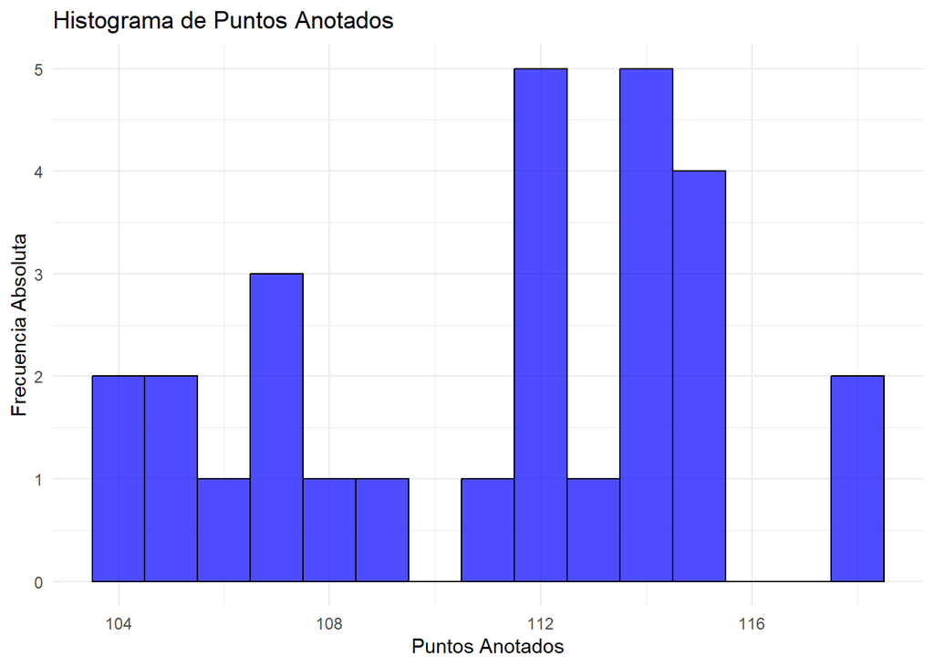

## Tabla 6. *Distribución de Frecuencia para el Porcentaje de Tiros de Campo Exitosos (FG%) de los Equipos en la Temporada 2018-19 de la NBA*

Esta tabla proporciona un desglose de la frecuencia de los cambios en el rendimiento del equipo de la NBA en porcentaje de tiros de campo (FG%) entre 2018 y 2019. en la estación del año. Muestra la frecuencia absoluta de diferentes rangos de porcentaje de tiro para el equipo, así como la frecuencia acumulada y el porcentaje acumulado. Esta información proporciona una visión general del desglose del equipo en términos de eficiencia de tiro.

| FG% | Frecuencia | Frecuencia Acumulada | Porcentaje Acumulado |
| --- | --- | --- | --- |
| 43.3 | 1 | 1 | 3.33 |
| 44.0 | 1 | 2 | 6.67 |
| 44.4 | 1 | 3 | 10.00 |
| 44.7 | 1 | 4 | 13.33 |
| 44.8 | 1 | 5 | 16.67 |
| 44.9 | 2 | 7 | 23.33 |
| 45.0 | 2 | 9 | 30.00 |
| 45.1 | 1 | 10 | 33.33 |
| 45.3 | 1 | 11 | 36.67 |
| 45.4 | 2 | 13 | 43.33 |
| 45.6 | 1 | 14 | 46.67 |
| 45.9 | 1 | 15 | 50.00 |
| 46.4 | 1 | 16 | 53.33 |
| 46.5 | 1 | 17 | 56.67 |
| 46.6 | 1 | 18 | 60.00 |
| 46.7 | 1 | 19 | 63.33 |
| 46.8 | 2 | 21 | 70.00 |
| 47.0 | 1 | 22 | 73.33 |
| 47.1 | 2 | 24 | 80.00 |
| 47.3 | 1 | 25 | 83.33 |
| 47.4 | 1 | 26 | 86.67 |
| 47.5 | 1 | 27 | 90.00 |
| 47.6 | 1 | 28 | 93.33 |
| 47.8 | 1 | 29 | 96.67 |
| 49.1 | 1 | 30 | 100.00 |

## Figura 5. Gráfica de lineas de Porcentaje Acumulado de Tiros de Campo Exitosos (FG%) en la NBA temporada 2018-19

El gráfico de líneas muestra la distribución porcentual de tiros de campo exitosos en la NBA. El eje x muestra el rango de porcentaje de tiros de campo y el eje y muestra el porcentaje acumulado. Esta curva representa el porcentaje acumulado de equipos con eficiencia de tiro dentro de un rango determinado. La pendiente de la curva proporciona información sobre la densidad del equipo en diferentes niveles de precisión de tiro.

[figure not shown]

## Tabla 7. *Distribución de Frecuencia para Porcentaje de Tiros de Tres Puntos Exitosos (3P%)*

Esta tabla muestra el porcentaje de tiros de tres puntos (3P%) para los equipos de la NBA en 2018-19. Muestra la frecuencia absoluta para varios rangos de porcentaje, así como la frecuencia acumulada y el porcentaje acumulativo, proporcionando información detallada sobre los cambios en el desempeño de tres puntos de un equipo.

| 3P% | Frecuencia | Frecuencia Acumulada | Porcentaje Acumulado |
| --- | --- | --- | --- |
| 32.9 | 1 | 1 | 3.33 |
| 33.3 | 1 | 2 | 6.67 |
| 34.0 | 2 | 4 | 13.33 |
| 34.1 | 1 | 5 | 16.67 |
| 34.2 | 1 | 6 | 20.00 |
| 34.4 | 1 | 7 | 23.33 |
| 34.8 | 2 | 9 | 30.00 |
| 34.9 | 1 | 10 | 33.33 |
| 35.1 | 4 | 14 | 46.67 |
| 35.2 | 1 | 15 | 50.00 |
| 35.3 | 2 | 17 | 56.67 |
| 35.5 | 1 | 18 | 60.00 |
| 35.6 | 3 | 21 | 70.00 |
| 35.9 | 2 | 23 | 76.67 |
| 36.5 | 1 | 24 | 80.00 |
| 36.6 | 1 | 25 | 83.33 |
| 37.4 | 1 | 26 | 86.67 |
| 37.8 | 1 | 27 | 90.00 |
| 38.5 | 1 | 28 | 93.33 |
| 38.8 | 1 | 29 | 96.67 |
| 39.2 | 1 | 30 | 100.00 |

## Figura 6. Histograma de porcentaje de tiros de tres puntos exitosos (3P%)

Este histograma presenta la distribución de los porcentajes de tiros de tres puntos exitosos (3P%) para los equipos de la NBA durante la temporada 2018-19. Cada barra representa un rango de porcentajes, y la altura de la barra indica la frecuencia absoluta de equipos que caen dentro de ese rango.

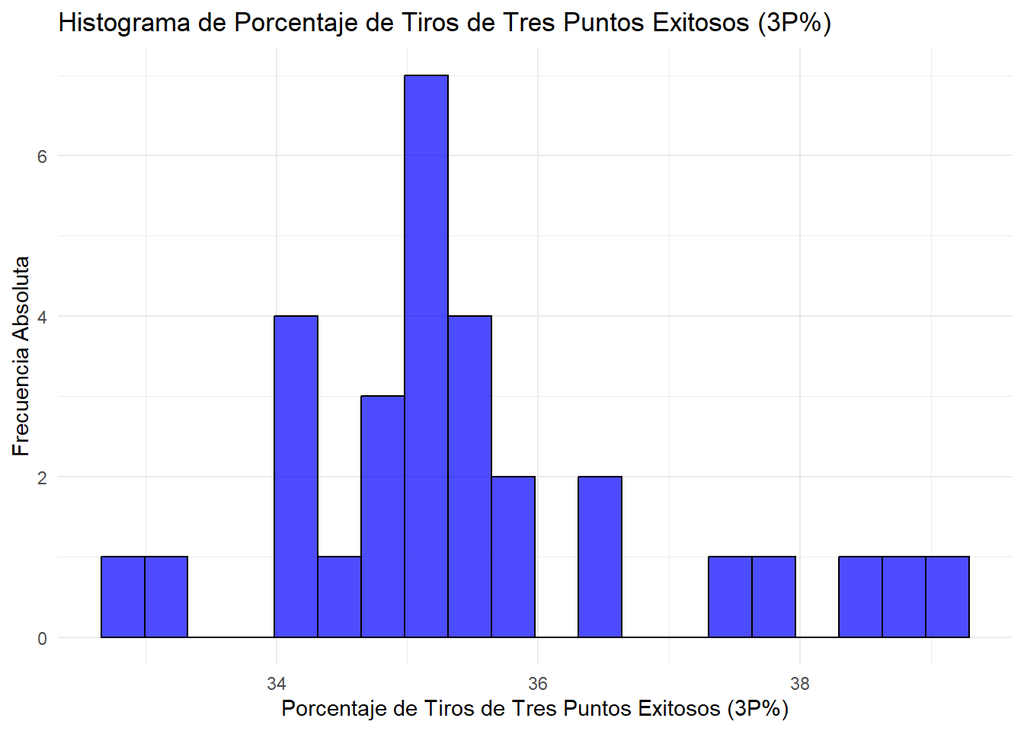

## Tabla 8. *Distribución de Frecuencia para Tiros Libres Exitosos (FTM) en la Temporada 2018-19*

La tabla presenta la distribución de frecuencia de los tiros libres exitosos (FTM) para los equipos de la NBA durante la temporada 2018-19.

| FTM | Frecuencia_Absoluta | Frecuencia_Acumulada | Frecuencia_Relativa | Frecuencia_Relativa_Acumulada |
| --- | --- | --- | --- | --- |
| 15.0 | 1 | 1 | 0.03 | 0.03 |
| 15.1 | 1 | 2 | 0.03 | 0.07 |
| 15.6 | 1 | 3 | 0.03 | 0.10 |
| 15.8 | 2 | 5 | 0.07 | 0.17 |
| 16.2 | 1 | 6 | 0.03 | 0.20 |
| 16.3 | 2 | 8 | 0.07 | 0.27 |
| 16.4 | 1 | 9 | 0.03 | 0.30 |
| 16.5 | 1 | 10 | 0.03 | 0.33 |
| 17.2 | 1 | 11 | 0.03 | 0.37 |
| 17.3 | 1 | 12 | 0.03 | 0.40 |
| 17.6 | 2 | 14 | 0.07 | 0.47 |
| 17.7 | 2 | 16 | 0.07 | 0.53 |
| 17.8 | 2 | 18 | 0.07 | 0.60 |
| 17.9 | 1 | 19 | 0.03 | 0.63 |
| 18.1 | 1 | 20 | 0.03 | 0.67 |
| 18.4 | 2 | 22 | 0.07 | 0.73 |
| 18.8 | 2 | 24 | 0.07 | 0.80 |
| 19.0 | 2 | 26 | 0.07 | 0.87 |
| 19.1 | 1 | 27 | 0.03 | 0.90 |
| 19.3 | 1 | 28 | 0.03 | 0.93 |
| 21.2 | 1 | 29 | 0.03 | 0.97 |
| 22.6 | 1 | 30 | 0.03 | 1.00 |

## Figura 7. Histograma de Tiros Libres Exitosos (FTM) en la Temporada 2018-19 de la NBA

Este histograma visualiza la distribución de la cantidad de tiros libres exitosos (FTM) por equipo en la temporada 2018-19 de la NBA. Cada barra representa un rango de valores de FTM, y la altura de la barra indica la frecuencia absoluta de equipos que registraron ese número de tiros libres exitosos.

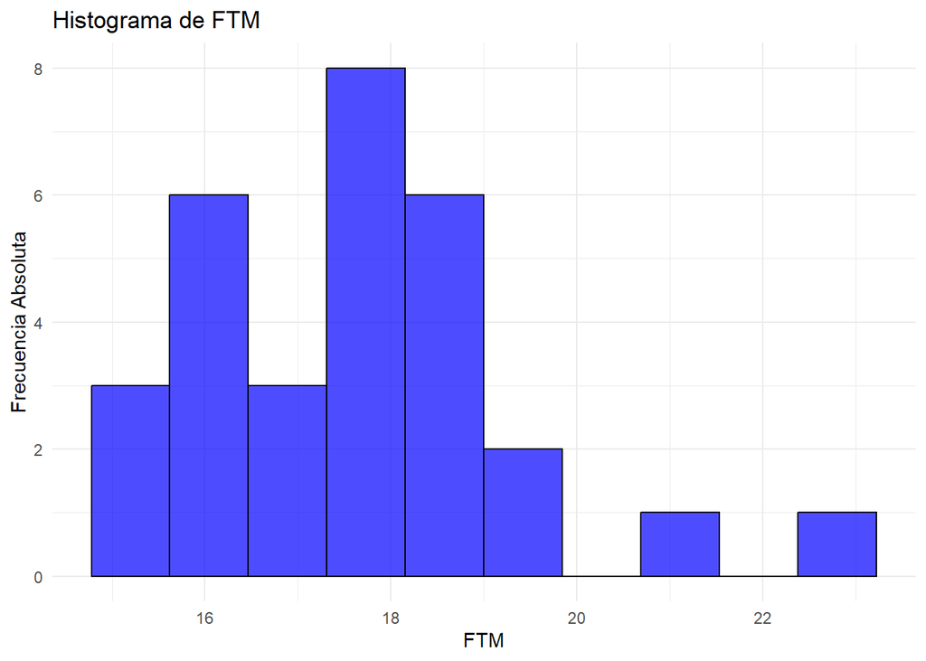

## Tabla 9. *Distribución de Frecuencia de Rebotes (REB) en la Temporada 2018-2019 de la NBA*

La tabla presenta una distribución de frecuencia de los rebotes (REB) obtenidos por los equipos de la NBA durante la temporada 2018-2019. La frecuencia absoluta muestra la cantidad de equipos que registraron un número específico de rebotes.

| Rebotes | Frecuencia_Absoluta | Frecuencia_Acumulada | Frecuencia_Relativa | Frecuencia_Relativa_Acumulada |
| --- | --- | --- | --- | --- |
| 40.4 | 1 | 1 | 0.03 | 0.03 |
| 41.8 | 1 | 2 | 0.03 | 0.07 |
| 42.1 | 1 | 3 | 0.03 | 0.10 |
| 42.4 | 1 | 4 | 0.03 | 0.13 |
| 42.7 | 1 | 5 | 0.03 | 0.17 |
| 42.9 | 1 | 6 | 0.03 | 0.20 |
| 43.0 | 1 | 7 | 0.03 | 0.23 |
| 43.8 | 1 | 8 | 0.03 | 0.27 |
| 44.5 | 1 | 9 | 0.03 | 0.30 |
| 44.7 | 2 | 11 | 0.07 | 0.37 |
| 44.8 | 1 | 12 | 0.03 | 0.40 |
| 45.0 | 1 | 13 | 0.03 | 0.43 |
| 45.2 | 1 | 14 | 0.03 | 0.47 |
| 45.3 | 1 | 15 | 0.03 | 0.50 |
| 45.4 | 2 | 17 | 0.07 | 0.57 |
| 45.5 | 1 | 18 | 0.03 | 0.60 |
| 46.1 | 1 | 19 | 0.03 | 0.63 |
| 46.2 | 1 | 20 | 0.03 | 0.67 |
| 46.3 | 1 | 21 | 0.03 | 0.70 |
| 46.4 | 2 | 23 | 0.07 | 0.77 |
| 46.6 | 2 | 25 | 0.07 | 0.83 |
| 47.3 | 1 | 26 | 0.03 | 0.87 |
| 47.8 | 1 | 27 | 0.03 | 0.90 |
| 48.0 | 1 | 28 | 0.03 | 0.93 |
| 48.1 | 1 | 29 | 0.03 | 0.97 |
| 49.7 | 1 | 30 | 0.03 | 1.00 |

## Figura 8. Gráfico de barras de Rebotes (REB) - Temporada 2018-2019 NBA

El siguiente gráfico de barras representa la distribución de frecuencia de rebotes (REB) para los equipos de la NBA en 2018-19.Cada barra del gráfico representa la frecuencia absoluta con la que un equipo registra una determinada cantidad de rebotes. Este análisis proporciona una representación visual de cómo se distribuyen los datos entre los equipos, destacando tendencias y cambios en el rendimiento de rebotes de un equipo a lo largo de una temporada.

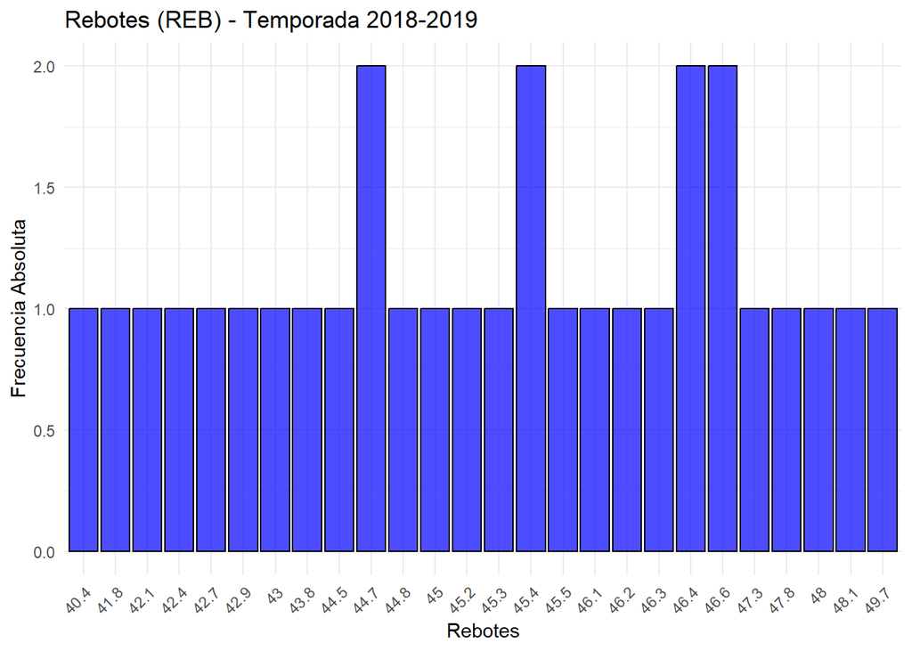

## Figura 9. Gráfica de Caja y Bigotes: Partidos Ganados (W) vs. Partidos Jugados (GP)

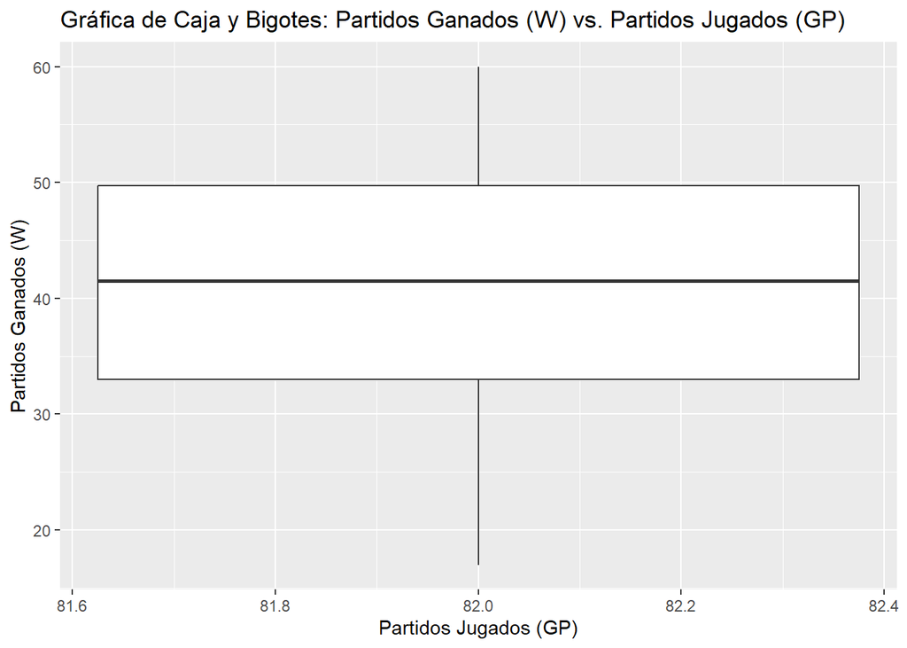